# Example Workflow

OJ Watson

2025-03-05

## 0. Create your vaccine counterfactuals

We first need to create a file inside `src/run_simulations` which is where we store what the vaccine counterfactuals are for the coverage to get what the coverage is for a specific country we read in one of the fits saved inside `src/run_simulations`. these are previously run fits of a covid-19 transmission model to excess mortality per country using `squire.page`

```r
# e.g. for Angola
fit <- readRDS("src/run_simulations/fits/AGO.rds")
```

To get the vaccine coverage we can use the following function

```r
get_vacc_coverage <- function(fit) {

  # create our vaccine allocation dataframe
  df <- data.frame(
    # convert everything to character for dates - just safer
    "date" = as.character(fit$parameters$tt_booster_doses + fit$inputs$start_date),
    "primary_doses" = fit$parameters$primary_doses,
    "booster_doses" = fit$parameters$booster_doses
  )

  return(df)

}

# so for angola
vac_df <- get_vacc_coverage(fit)
head(vac_df)
```

```
##         date primary_doses booster_doses
## 1 2019-11-29             0             0
## 2 2021-03-03           881             0
## 3 2021-03-04           881             0
## 4 2021-03-05           881             0
## 5 2021-03-06           881             0
## 6 2021-03-07           881             0
```

Let’s now assume we want to create two scenarios with 20% more and less vaccination:

```r
low_df <- vac_df %>%
  mutate(primary_doses = primary_doses*0.8,
         booster_doses = booster_doses*0.8,
         scenario = "Decrease")
high_df <- vac_df %>%
  mutate(primary_doses = primary_doses*1.2,
         booster_doses = booster_doses*1.2,
         scenario = "Increase")
```

Now we will need to assign the iso3c to these and save this to `src/run_simulations`

```r
write.csv(
  rbind(low_df, high_df) %>% mutate(iso3c = "AGO"),
  "src/run_simulations/vaccine_counterfactuals.csv",
  row.names = FALSE
)
```

And let’s do the same for South Africa:

```r
# and let's do the same for South Africa
zaf <- readRDS("src/run_simulations/fits/ZAF.rds")
zaf_vac_df <- get_vacc_coverage(zaf)

# let assume we want to create two scenarios with 20% more and less vaccination
low_df <- zaf_vac_df %>%
  mutate(primary_doses = primary_doses*0.8,
         booster_doses = booster_doses*0.8,
         scenario = "Decrease")
high_df <- zaf_vac_df %>%
  mutate(primary_doses = primary_doses*1.2,
         booster_doses = booster_doses*1.2,
         scenario = "Increase")

# we then combine these, and add these to the file that already exists
write.csv(
  rbind(
    # we read in as is to ensure it is a character
    read.csv("src/run_simulations/vaccine_counterfactuals.csv", as.is = TRUE),
    rbind(low_df, high_df) %>% mutate(iso3c = "ZAF")
  ),
  "src/run_simulations/vaccine_counterfactuals.csv",
  row.names = FALSE
)
```

This file is just an example but I will leave it to you to work out what your vaccine scenarios are over time

## 1. Run our simulations

The reason we created this counterfactual file in this directory is because this repo is set up using `orderly`, which is a package developed by Imperial MRC-GIDA (see mrc-ide on github) to make reproducible analysis simpler.

`orderly` repos have orderly tasks inside the `src/` directory in folders, with each folder a task. The files inside this are then processed by orderly and run before adding extra infrmation to the output so that we know exactly how this task was run (what packages, what files were used, what versions etc).

For now perhaps do not worry too much about it.

All countries that can be run are in the following file

```r
iso3cs <- readLines("analysis/iso3cs")
head(iso3cs)
```

```
## [1] "ABW" "AFG" "AGO" "ALB" "ARE" "ARG"
```

But in this example let’s just look at the two we have made counterfactuals for

```r
iso3cs <- c("AGO", "ZAF")
```

The simulations don’t take too long to run but we can run these in parallel for ease:

```
## [1] TRUE
```

Now let’s create our data frame that control what countries and counterfactuals we are simulating. so lets simulate for each of the two countries and each of the two scenarios.

```r
run_df <- expand.grid("iso3c" = iso3cs, scenario = c("Increase", "Decrease"))
```

And now we pass this to our parallel function call that will run the run_simulation task for each row in our data

What we have done is run the task run_simulation, which if they run correctly will return unique ids for each run:

```r
orderly_ids
```

```
## [1] "20250305-181942-3140f794" "20250305-181942-313f342d"
## [3] "20250305-181942-314089a9" "20250305-181942-313c8eba"
```

The actual runs and model outputs are initially stored in the draft folder each named with the id

We can then look in these and either analyse the outputs or look at the model plots generated. we may want to check this by looking at some summary plots from each run, which is saved by each task as plots/scenario_plot.pdf

So let’s merge all these into one and save it so we can have a look at it:

```r
pdfs <- file.path(
  list.files(file.path(here::here(), "draft/run_simulations"), full.names = TRUE),
  "plots/scenario_plot.pdf")
dir.create("analysis/plots")
pdftools::pdf_combine(pdfs, file.path(here::here(), "analysis/plots/scenario_plots.pdf"))
```

Let’s assume these all look great then we commit these to the archive, which moves them into archive

We have this separation of draft so that we only commit the file runs we want to and we are happy with.

Once we have committed them it may be a good idea to make a store of these ids

## 2. Analysis

Now we may want to analyse the raw simulation outputs, which we can read in from the archive runs within `data/dih_out.rds`

First find the file paths and read in the results

```r
res_paths <- file.path("archive/run_simulations/", orderly_ids, "data/dih_out.rds")
df <- lapply(res_paths, readRDS)
```

One thing to be cautious of is that each of the tasks out includes the baseline simulation with no change in vaccination. So we will remove the baseline in all outputs except for one per country so we don’t double count this later on:

```r
for(i in which(duplicated(run_df$iso3c))) {
  df[[i]] <- df[[i]] %>% filter(scenario != "Baseline")
}

# now we will make it into one large table
df <- do.call(rbind, df)
head(df)
```

```
## # A tibble: 6 × 7
##   date       replicate deaths infections hospitalisations scenario iso3c
##   <date>         <int>  <dbl>      <dbl>            <dbl> <chr>    <chr>
## 1 2019-11-30         1      0          0                0 Baseline AGO
## 2 2019-11-30         2      0          0                0 Baseline AGO
## 3 2019-11-30         3      0          0                0 Baseline AGO
## 4 2019-11-30         4      0          0                0 Baseline AGO
## 5 2019-11-30         5      0          0                0 Baseline AGO
## 6 2019-11-30         6      0          0                0 Baseline AGO
```

The results are a table of the deaths, infections and hospitalisations for each task run. so here there are two scenarios and two iso3cs run. the outputs have one row for each date, and also for each replicate run (the model fits are based on 100 draws from the model fitting exercise)

So to work out the totals for each scenario and country we first need to work these out for each replicate before then calculating summary statistics

```
## # A tibble: 6 × 11
##   iso3c scenario deaths_med hospitalisations_med infections_med deaths_025
##   <chr> <chr>         <dbl>                <dbl>          <dbl>      <dbl>
## 1 AGO   Baseline     22500.               93692.      10600161.     21359.
## 2 AGO   Decrease     24171.               98946.      11146080.     23159.
## 3 AGO   Increase     21528.               89470.      10133096.     19680.
## 4 ZAF   Baseline    252451.             1244896.      81289938.    248515.
## 5 ZAF   Decrease    260208.             1284108.      82843806.    256404.
## 6 ZAF   Increase    244976.             1203674.      79635449.    237844.
## # ℹ 5 more variables: hospitalisations_025 <dbl>, infections_025 <dbl>,
## #   deaths_975 <dbl>, hospitalisations_975 <dbl>, infections_975 <dbl>
```

Great the above show that there are more total deaths, hops, infxs in the Decrease scenario (where we decreased the vaccination) than the baseline and vice versa for Increase

And if we wanted to visualise this over time we can do this as well this is similar to the plots output in the tasks in plots/scenario_plots.pdf

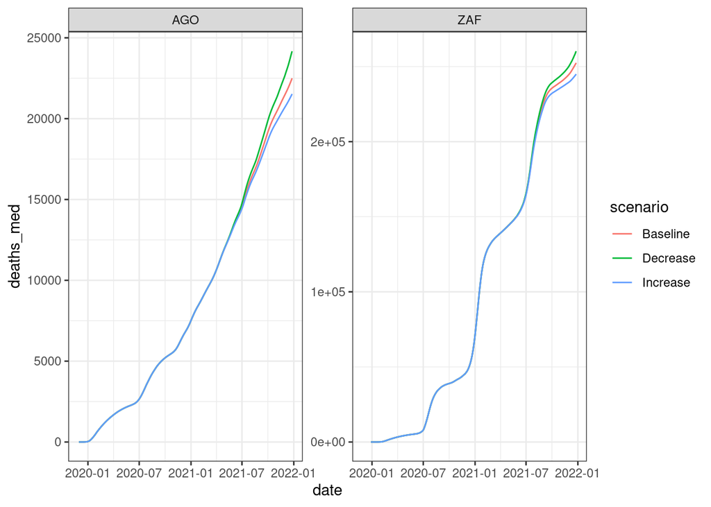

```r
df %>%
  group_by(iso3c, scenario, replicate) %>%
  mutate(
    across(
      c(deaths, hospitalisations, infections), ~cumsum(.x)
    )) %>%
  group_by(iso3c, scenario, date) %>%
  summarise(
    across(
      c(deaths, hospitalisations, infections), ~median(.x, na.rm=TRUE),
      .names = "{col}_med"
    ),
    across(
      c(deaths, hospitalisations, infections), ~quantile(.x, 0.025, na.rm=TRUE),
      .names = "{col}_025"
    ),
    across(
      c(deaths, hospitalisations, infections), ~quantile(.x, 0.975, na.rm=TRUE),
      .names = "{col}_975"
    ),
    .groups = "drop"
  ) %>%
  ggplot(aes(date, deaths_med, color = scenario)) +
  geom_line() +
  facet_wrap(~iso3c, scales = "free_y") +
  theme_bw()
```

## 3. Fin. Next Steps

Hopefully that gives you enough to get started with. next steps would be to populate the `src/run_simulations/vaccine_counterfactuals.csv` with the vaccine counterfactuals you want to look into and to then repeat the simulations for all the countries of interest. Hopefully then it is just a matter of deciding how you want to present the results :)